# lab2_Visual

```python
import matplotlib.pyplot as plt
import numpy as np
import pandas as pd
```

```python
import seaborn as sns
```

```python
import matplotlib.pyplot as plt
```

```python
sns.get_dataset_names()
```

```
['anagrams',
 'anscombe',
 'attention',
 'brain_networks',
 'car_crashes',
 'diamonds',
 'dots',
 'dowjones',
 'exercise',
 'flights',
 'fmri',
 'geyser',
 'glue',
 'healthexp',
 'iris',
 'mpg',
 'penguins',
 'planets',
 'seaice',
 'taxis',
 'tips',
 'titanic']
```

## `Car Crashes` (Histogram)

```python
car = sns.load_dataset('car_crashes')
print(car)
```

```
    total  speeding  alcohol  not_distracted  no_previous  ins_premium
0    18.8     7.332    5.640          18.048       15.040       784.55  \
1    18.1     7.421    4.525          16.290       17.014      1053.48
2    18.6     6.510    5.208          15.624       17.856       899.47
3    22.4     4.032    5.824          21.056       21.280       827.34
4    12.0     4.200    3.360          10.920       10.680       878.41
5    13.6     5.032    3.808          10.744       12.920       835.50
6    10.8     4.968    3.888           9.396        8.856      1068.73
7    16.2     6.156    4.860          14.094       16.038      1137.87
8     5.9     2.006    1.593           5.900        5.900      1273.89
9    17.9     3.759    5.191          16.468       16.826      1160.13
10   15.6     2.964    3.900          14.820       14.508       913.15
11   17.5     9.450    7.175          14.350       15.225       861.18
12   15.3     5.508    4.437          13.005       14.994       641.96
13   12.8     4.608    4.352          12.032       12.288       803.11
```

[output cut: 90 more lines]

- The first graph shows the `total` number of drivers involved in `fatal collisions`.
- The second graph shows how many `fatal collisions` happened because of `speeding`.
- The third graph shows drivers involved in `fatal collisions` who were `alcohol impaired`.
- The final graph shows drivers involved in `fatal collisions` who were `not distracted`.

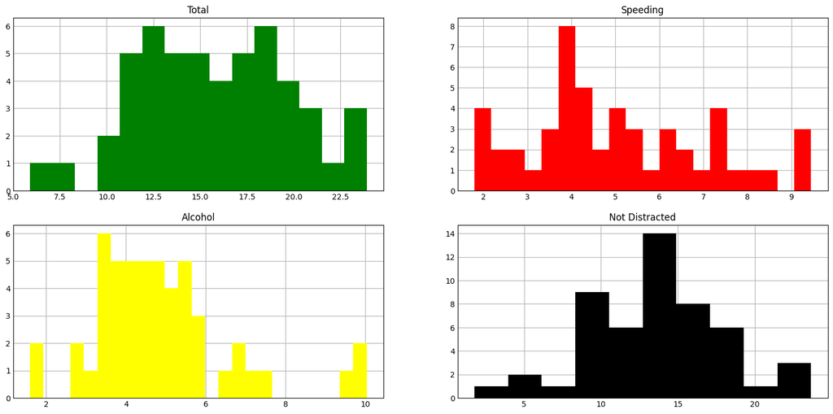

```python
x1 , y1 = plt.subplots(2,2,figsize=[15,7])

y1[0,0].hist(car['total'],bins = 15,color='green')
y1[0,0].set_title('Total')
y1[0,1].hist(car['speeding'], bins = 20, color='red')
y1[0,1].set_title('Speeding')
y1[1,0].hist(car['alcohol'], bins = 25, color='yellow')
y1[1,0].set_title('Alcohol')
y1[1,1].hist(car['not_distracted'], color='black')
y1[1,1].set_title('Not Distracted')
plt.show()
```

## `Health` (Scatter)

```python
Health = sns.load_dataset('healthexp')
print(Health)
```

```
     Year        Country  Spending_USD  Life_Expectancy
0    1970        Germany       252.311             70.6
1    1970         France       192.143             72.2
2    1970  Great Britain       123.993             71.9
3    1970          Japan       150.437             72.0
4    1970            USA       326.961             70.9
..    ...            ...           ...              ...
269  2020        Germany      6938.983             81.1
270  2020         France      5468.418             82.3
271  2020  Great Britain      5018.700             80.4
272  2020          Japan      4665.641             84.7
273  2020            USA     11859.179             77.0

[274 rows x 4 columns]
```

First graph shows the relation of `Year` with Spending_USD and Life_Expectancy. Second graph shows the relation of `Spending_USD` with Year and Life_Expectancy. Third graph shows the relation of `Life_Expectancy` with Year and Spending_USD.

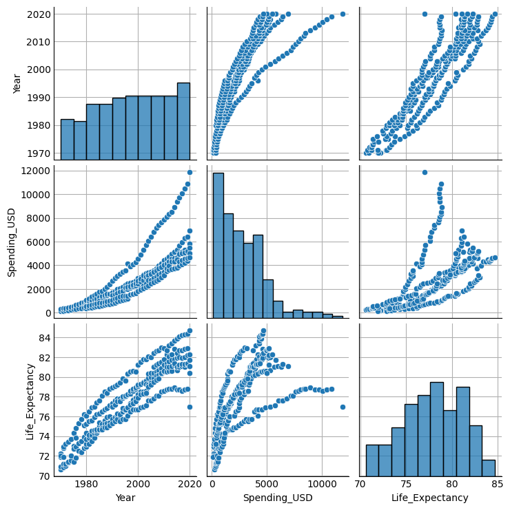

```python
sns.pairplot(Health)
plt.show()
```

## `Boxplot`

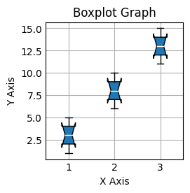

```python
data = [[1, 2, 3, 4, 5], [6, 7, 8, 9, 10], [11, 12, 13, 14, 15]]

plt.boxplot(data, patch_artist=True, medianprops=dict(color='white'), notch=True)

plt.title("Boxplot Graph")
plt.xlabel("X Axis")
plt.ylabel("Y Axis")

plt.show()
```

## `Bar Graph`

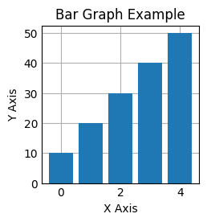

```python
x = np.arange(5)

height = np.array([10, 20, 30, 40, 50])

plt.bar(x, height)

plt.title("Bar Graph Example")
plt.xlabel("X Axis")
plt.ylabel("Y Axis")

plt.show()
```

This bar graph shows five inputs of 5 diferent values.